# lubridate practice

Tal G

2019-04-29

# Date and time in R

there are several types of R objects

all the explanation below are taken from the [**Handling date-times in R Cole Beck**](http://biostat.mc.vanderbilt.edu/wiki/pub/Main/ColeBeck/datestimes.pdf) manual

1. Date Class

The simplest data type to use for dates is the ”Date” class. these will be internally stored as integers.The specific date used to index your dates is called the origin. Typically programming languages use a default origin of 1970-01-01, though it is really day zero, not day one (negative values are perfectly valid).

```r
unclass(Sys.Date())
```

```
## [1] 18015
```

```r
Sys.Date() - as.Date("1970-01-01")
```

```
## Time difference of 18015 days
```

2. POSIXt Date-Time Class

Dates are pretty simple and most of the operations that we could use for them will also apply to date-time variables. There are at least three good options for date-time data types: built-in POSIXt, chron package, lubridate package. There are two POSIXt types, POSIXct and POSIXlt. ”ct” can stand for calendar time, it stores the number of seconds since the origin. ”lt”, or local time, keeps the date as a list of time attributes (such as ”hour” and ”mon”)

#### current time as POSIXct:

```r
unclass(Sys.time())
```

```
## [1] 1556570382
```

```r
Sys.time()-1556568634
```

```
## [1] "1970-01-01 02:29:08 IST"
```

#### current time as POSIXit:

```r
unclass(as.POSIXlt(Sys.time()))
```

```
## $sec
## [1] 42.50493
##
## $min
## [1] 39
##
## $hour
## [1] 23
##
## $mday
## [1] 29
##
## $mon
## [1] 3
##
## $year
## [1] 119
##
## $wday
## [1] 1
##
## $yday
## [1] 118
##
## $isdst
## [1] 1
##
## $zone
## [1] "IDT"
##
## $gmtoff
## [1] 10800
##
## attr(,"tzone")
## [1] ""    "IST" "IDT"
```

- usually POSIXct is easier to work with… with lubridate you don’t need to worry about it

**in this workshop we will give introduction to ‘lubridate’ package**

# Part 1 - simple example

```r
library(tidyverse)
library(lubridate)
library(hms)
library(scales)
library(knitr)
theme_set(theme_bw())
```

```r
timeSample <- tibble(
  date_1 = c("02-10-2019", "2/10/19"),
  date_2 = c("2019 10 02", "19/10/2"),
  datetime_1 = c("02-10-2019 19:00:00", "02-10-2019 7:00:00PM")
)
```

| date_1 | date_2 | datetime_1 |
| --- | --- | --- |
| 02-10-2019 | 2019 10 02 | 02-10-2019 19:00:00 |
| 2/10/19 | 19/10/2 | 02-10-2019 7:00:00PM |

### Convert to Datetime object (class POSIXCT/POSIXIT)

`lubridate` has multiple functions that convert factor (or any other class) to dates. For example:

- `ymd()` (year, month, day)
- `mdy()`
- `dmy()`

The difference is the order of the time variables–you need to choose the one that fits for your date type.

e.g. in the `date_1` column the date is built in the day-month-year format so I use the dmy function

```r
timeSample %>%
  mutate(date_1 = dmy(date_1)) %>%
  kable()
```

| date_1 | date_2 | datetime_1 |
| --- | --- | --- |
| 2019-10-02 | 2019 10 02 | 02-10-2019 19:00:00 |
| 2019-10-02 | 19/10/2 | 02-10-2019 7:00:00PM |

in date_2 column the date is built in format of year-month-day so i use the ymd function

```r
timeSample %>%
  mutate(date_1 = dmy(date_1),
         date_2 = ymd(date_2)) %>%
  kable()
```

| date_1 | date_2 | datetime_1 |
| --- | --- | --- |
| 2019-10-02 | 2019-10-02 | 02-10-2019 19:00:00 |
| 2019-10-02 | 2019-10-02 | 02-10-2019 7:00:00PM |

**Note** the only thing that matters is the order of the day/month/year. The separators can change (‘:’ or ‘/’ or ‘-’ etc.) and lubridate can handle it…the same goes for 02 or 2, 2019 or 19.

**Really cool!!**

`lubridate` can also handle date and time object in the same manner… * note - can translate AM/PM to the right 24 clock hour

```r
timeSample <- timeSample %>%
  mutate(date_1 = dmy(date_1),
         date_2 = ymd(date_2),
         datetime_1 = dmy_hms(datetime_1))
```

| date_1 | date_2 | datetime_1 |
| --- | --- | --- |
| 2019-10-02 | 2019-10-02 | 2019-10-02 19:00:00 |
| 2019-10-02 | 2019-10-02 | 2019-10-02 19:00:00 |

### Time zones

When dealing with times in R it’s super important to pay attention to time zones

If you don’t specify the time zone, the default will be UTC. This can cause problems later on if you do all kind of time calculations and don’t understand why you get weird numbers (;

The `force_tz` function will take the time as it and change the time zone (in the ‘back office’) to the required one. It’s good for cases where you didn’t specify the time zone for your data beforehand and now you want to fix it.

```r
tz(timeSample$datetime_1)
```

```
## [1] "UTC"
```

```r
timeSample$datetime_1 <- force_tz(timeSample$datetime_1, "Asia/Jerusalem")
tz(timeSample$datetime_1)
```

```
## [1] "Asia/Jerusalem"
```

The `with_tz` function will **convert** your time zone to a different one. this function is good for cases where you want to know the time in different places

```r
timeSample$datetime_utc <- with_tz(timeSample$datetime_1, "UTC")
```

| date_1 | date_2 | datetime_1 | datetime_utc |
| --- | --- | --- | --- |
| 2019-10-02 | 2019-10-02 | 2019-10-02 19:00:00 | 2019-10-02 16:00:00 |
| 2019-10-02 | 2019-10-02 | 2019-10-02 19:00:00 | 2019-10-02 16:00:00 |

**The best practice is to specify the timezone in first place**

```r
ymd_hms("2019-07-20 08:35:00", tz = "Asia/Jerusalem")
```

```
## [1] "2019-07-20 08:35:00 IDT"
```

### Other nice functions in `lubridate`

```r
days_in_month(today()) # how many days in this month?
```

```
## Apr
##  30
```

```r
days_in_month(today() + 31) # how many day in the month 31 days from now?
```

```
## May
##  31
```

```r
per <- period(hours = 10, minutes = 5) # define a period you can add to other date time...
per # a period class object
```

```
## [1] "10H 5M 0S"
```

```r
Sys.time() + per
```

```
## [1] "2019-04-30 09:44:44 IDT"
```

```r
Sys.time() - per
```

```
## [1] "2019-04-29 13:34:44 IDT"
```

```r
difftime(Sys.time() + per, Sys.time(), unit = "hours")
```

```
## Time difference of 10.08333 hours
```

```r
difftime(Sys.time() + period(week = 3), Sys.time(), unit = "day")
```

```
## Time difference of 21 days
```

```r
exmaple_interval<- interval(start = dmy("01-04-2019"),end = dmy("01-06-2019"),tz="Asia/Jerusalem") # create time interval class
exmaple_interval
```

```
## [1] 2019-04-01 03:00:00 IDT--2019-06-01 03:00:00 IDT
```

```r
today() %within% exmaple_interval
```

```
## [1] TRUE
```

```r
quarter(Sys.time(), with_year = T) # the qurater of the year...
```

```
## [1] 2019.2
```

## Part 2 - Taxi data frame

Import the data

```r
taxi <- read_csv("taxi.csv")
```

Convert to time class (“POSIXct” or “POSIXt” )

```r
class(taxi$trip_start)
```

```
## [1] "POSIXct" "POSIXt"
```

```r
class(taxi$trip_end)
```

```
## [1] "POSIXct" "POSIXt"
```

```r
taxi <- taxi %>%
  mutate(trip_start = ymd_hms(trip_start, tz = "America/Chicago"),
         trip_end = ymd_hms(trip_end, tz = "America/Chicago"))
```

### What is the week-day with the highest number of taxi trips?

`lubridate` has a series of functions that extract different variables out of the datetime

- `day()`
- `month()`
- `year()`
- `week()`
- `hour()`
- etc.

```r
# If label is false then is will show the week day numbers (1:7)
wday(taxi$trip_start, label = TRUE) %>% head()
```

```
## [1] Wed Fri Sun Sat Thu Fri
## Levels: Sun < Mon < Tue < Wed < Thu < Fri < Sat
```

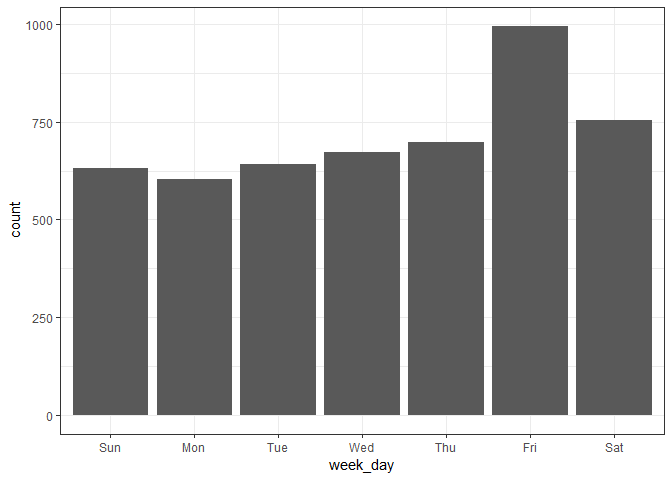

```r
taxi %>%
  mutate(week_day = wday(trip_start, label = TRUE)) %>%
  ggplot(aes(week_day)) +
  geom_bar()
```

Friday is the most busy day…

### What is the duration of each taxi trip?

`?difftime`

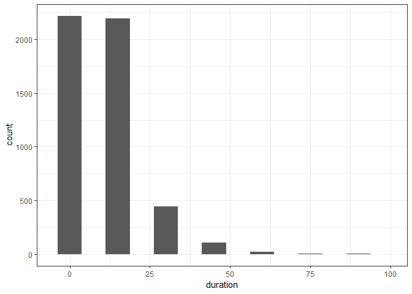

```r
taxi <- taxi %>%
  mutate(duration = difftime(trip_end, trip_start,
                             units = "mins")) %>%
  filter(duration < 100) #remove the abnormally long rides

taxi %>%
  ggplot(aes(duration)) +
  geom_histogram(bins = 15) +
  xlim(-5, 100)
```

### It seems that trips with duration below 15 mins default to zero…

Let’s assume that this is a mistake and change all the zero duration to a five minus drive

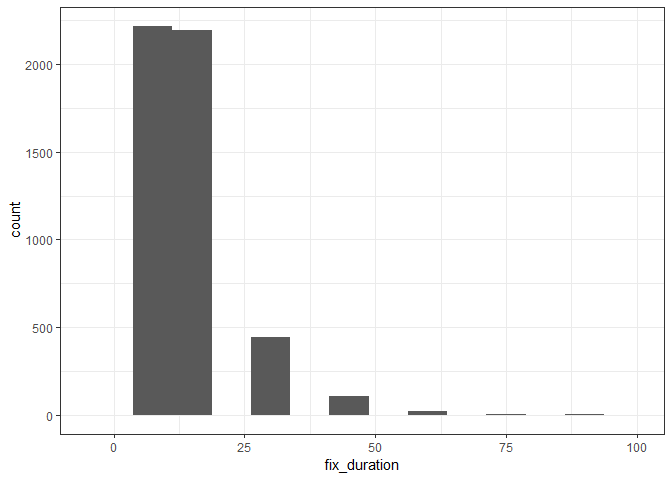

```r
five_min <- as.period(5, unit = "mins") # create five minute object
taxi <- taxi %>%

  # if the duration is 0 add five minutes
  mutate(alt_end_time = ifelse(duration == 0,
                               trip_end + five_min,
                               trip_end)) %>%
  # the output is in numeric format - change to datetime format and don't forget the time zone
  mutate(alt_end_time = as_datetime(alt_end_time, tz = "America/Chicago")) %>%

  # fix the duration
  mutate(fix_duration = difftime(alt_end_time, trip_start,
                                 units = "mins"))
taxi %>%
  filter(fix_duration < 100) %>%
  ggplot(aes(fix_duration)) +
  geom_histogram(bins = 15) +
  xlim(-5, 100)
```

# When are the longest trips? Morning, noon or night?

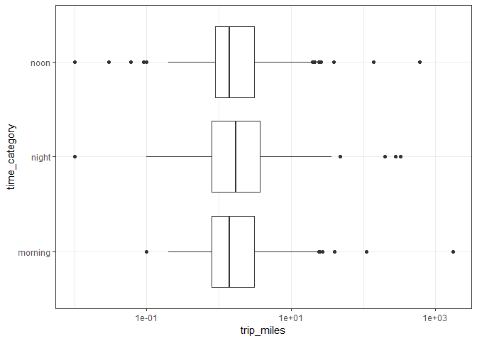

```r
taxi <- taxi %>%
  mutate(hour = hour(trip_start),
         time_category = case_when(
           between(hour, 5, 12) ~ "morning",
           between(hour, 12, 18) ~ "noon",
           TRUE ~ "night"
         ))
ggplot(taxi, aes(time_category, trip_miles)) +
  geom_boxplot() +
  scale_y_log10() +
  coord_flip()
```

# Round dates and times

the unit can be other combinations as well…

e.g.

- `"2 day"`
- `"5 mins"`
- `"quarter"`

```r
(taxi <- taxi %>%
  mutate(trip_start = round_date(trip_start,
                                 unit = "1 hour")))
```

```
## # A tibble: 4,992 x 16
##       X1 taxi_id trip_start          trip_end            trip_miles  fare
##    <int>   <int> <dttm>              <dttm>                   <dbl> <dbl>
##  1     1      85 2016-01-13 06:00:00 2016-01-13 06:15:00       0.4   4.5
##  2     2    2776 2016-01-22 10:00:00 2016-01-22 09:45:00       0.7   4.45
##  3     3    3168 2016-01-31 22:00:00 2016-01-31 21:30:00       0    42.8
##  4     4    4237 2016-01-23 18:00:00 2016-01-23 17:30:00       1.1   7
##  5     5    5710 2016-01-14 06:00:00 2016-01-14 06:00:00       2.71 10.2
##  6     6    1987 2016-01-08 18:00:00 2016-01-08 18:45:00       6.2  17.8
##  7     7    4986 2016-01-14 05:00:00 2016-01-14 05:00:00      18.4  45
##  8     8    6400 2016-01-26 04:00:00 2016-01-26 04:15:00       0.2   3.75
##  9     9    7418 2016-01-22 12:00:00 2016-01-22 11:45:00       0     5
## 10    10    6450 2016-01-07 21:00:00 2016-01-07 21:15:00       0     3.25
## # ... with 4,982 more rows, and 10 more variables: tips <dbl>,
## #   tolls <dbl>, trip_total <dbl>, payment_type <chr>, company <int>,
## #   duration <time>, alt_end_time <dttm>, fix_duration <time>, hour <int>,
## #   time_category <chr>
```

Other functions are `floor_date()` and `ceiling_date()` that will round the time down or up respectively

### Plots:

A basic plot

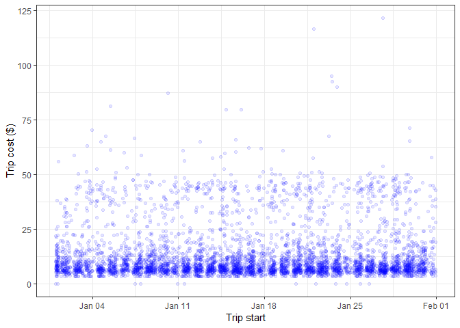

```r
(p <- ggplot(taxi, aes(trip_start, fare)) +
  geom_point(color = "blue", alpha = 0.1) +
  xlab("Trip start") + ylab("Trip cost ($)"))
```

To control the time axis use `scale_x_datetime()` or `scale_x_date()` if you only have date object

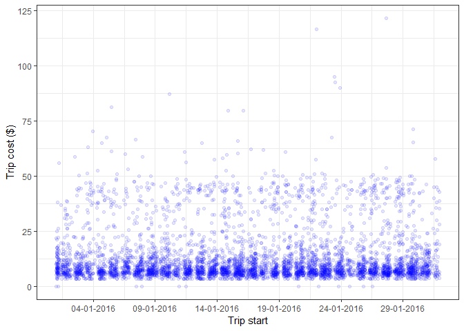

```r
p + scale_x_datetime(date_breaks = "5 day",
                     labels = date_format("%d-%m-%Y"))
```

The `date_break` argument controls for the tick mark

The `labels` argument controls for the label of your data

Note that the syntax here is different…

before each time variable, you need to add % sign, then the symbol for the time argument and the desired separator

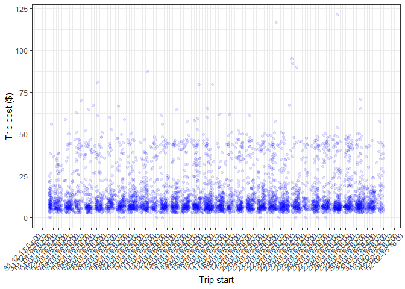

```r
p + scale_x_datetime(date_breaks = "12 hours",
                     labels = date_format("%d-%m-%y %H:%M")) +
  theme(axis.text.x = element_text(angle = 45, hjust = 1))
```

How to show only some of the time series

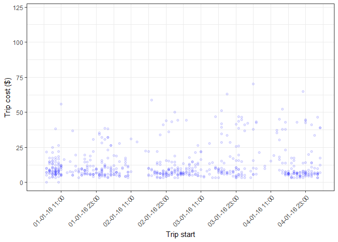

```r
start_time <- ymd_hms("2016-01-01 06:00:00", tz = "Asia/Jerusalem")
end_time <- ymd_hms("2016-01-05 06:00:00", tz = "Asia/Jerusalem")
# create a start and end time R object
start_end <- c(start_time, end_time)
p + scale_x_datetime(limits = start_end,
                     date_breaks = "12 hours",
                     labels = date_format("%d-%m-%y %H:%M")) +
  theme(axis.text.x = element_text(angle = 45, hjust = 1))
```

## By hour plots

If you want to plot hourly patterns there are 2 options

#### 1. use the `hms` package that can extract only the time variable from the date-time

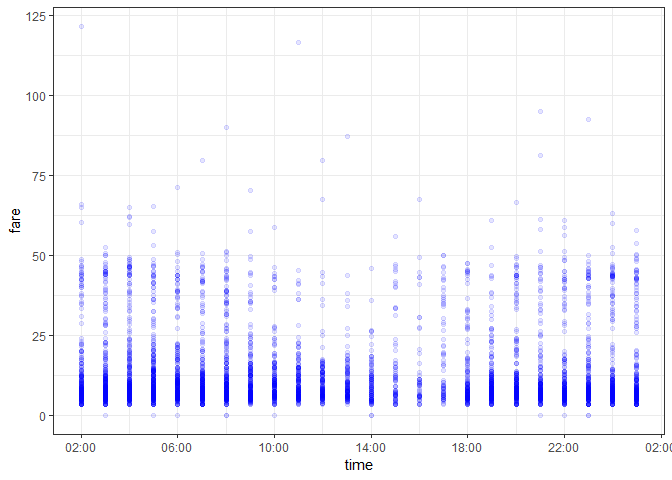

```r
taxi <- taxi %>%
  mutate(time = as.hms(trip_start))
ggplot(taxi, aes(time, fare)) +
  geom_point(color = "blue", alpha = 0.1) +
  scale_x_time(labels = function(x) strftime(x, "%H:%M"))
```

#### Option 2

Give one fake date to all the observation and customize with the `scale_x_datetime()` arguments

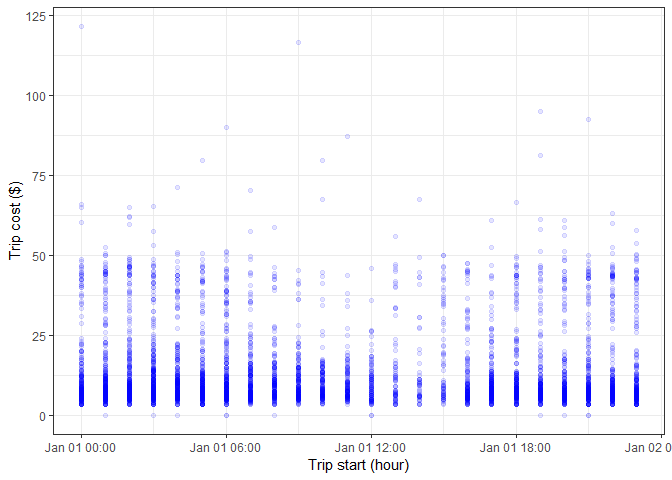

```r
taxi <- taxi %>%
  mutate(fake_date = ymd_hms(paste("2000-01-01", time)))
(p_2 <- ggplot(taxi, aes(fake_date, fare)) +
    geom_point(color = "blue", alpha = 0.1) +
    xlab("Trip start (hour)") +
    ylab("Trip cost ($)"))
```

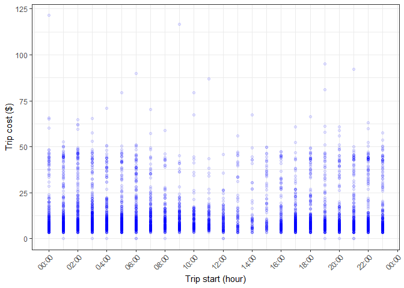

```r
p_2 +
  scale_x_datetime(date_breaks = "2 hours",
                   labels = date_format("%H:%M")) +
  theme(axis.text.x = element_text(angle = 45, hjust = 1))
```